# Introduction to R Studio

Giulia Grisot gg524@cam.ac.uk

November 2022

# Introduction

RStudio allows the user to run R in a user-friendly environment. It is *open-source* (i.e. free) and used by millions of users, meaning that it is *always kept up to date* and improved with new functions, and that there is *plenty of online support available* for most of the issues you might encounter (see https://stackoverflow.com).

There are also *numerous R related tutorials and/or resources* that you will be able to find online.

# RStudio interface

The usual Rstudio screen has four windows:

1. Console.
2. Workspace and history.
3. Files, plots, packages and help.
4. The R script(s) and data view.

[figure not shown]

The R script is where you keep a record of your work. For Stata users this would be like the do-file, for SPSS users is like the syntax and for SAS users the SAS program.

[figure not shown]

To create a new R script you can either go to File -> New -> R Script, or click on the icon with the “+” sign and select “R Script”, or simply press Ctrl+Shift+N. Make sure to save the script.

[figure not shown]

[figure not shown]

[figure not shown]

[figure not shown]

# Workspace tab

The workspace tab stores any object, value, function or anything you create during your R session. In the example below, if you click on the dotted squares you can see the data on a screen to the left.

[figure not shown]

# History tab

The history tab keeps a record of all previous commands. It helps when testing and running processes. Here you can either **save** the whole list or you can **select** the commands you want and send them to an R script to keep track of your work.

In this example, we select all and click on the “To Source” icon, a window on the left will open with the list of commands. Make sure to save the ‘untitled1’ file as an *.R script.

[figure not shown]

# Changing the working directory

[figure not shown]

[figure not shown]

# Setting a default working directory

[figure not shown]

# Packages tab

The package tab shows the list of add-ons included in the installation of RStudio. If checked, the package is loaded into R, if not, any command related to that package won’t work, you will need select it. You can also install other add-ons by clicking on the ‘Install Packages’ icon. Another way to activate a package is by typing, for example, library(foreign). This will automatically check the --foreign package (it helps bring data from proprietary formats like Stata, SAS or SPSS).

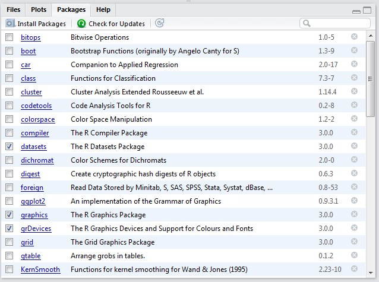

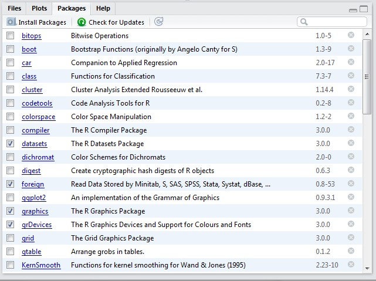

# Installing a package

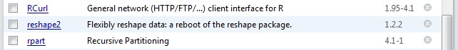

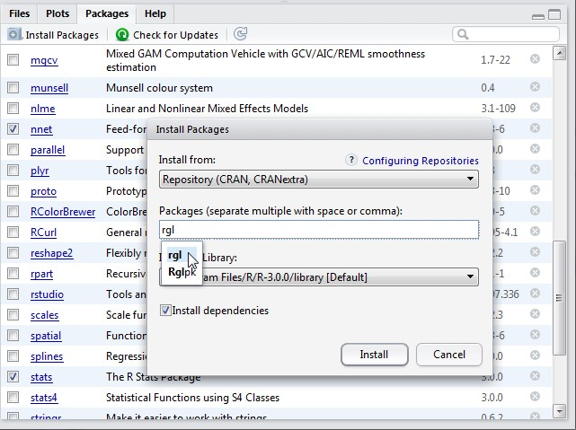

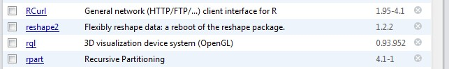

# Plots tab (1)

[figure not shown]

# Plots tab (2)

[figure not shown]

# Plots tab (3) – Graphs export

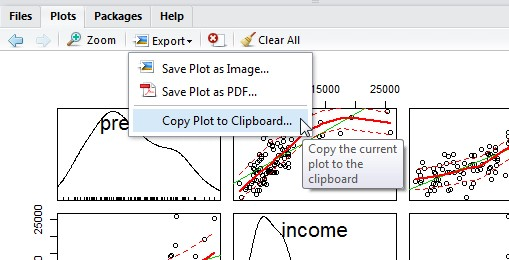

To extract the graph, click on “Export” where you can save the file as an image (PNG, JPG, etc.) or as PDF, these options are useful when you only want to share the graph or use it in a LaTeX document. Probably, the easiest way to export a graph is by copying it to the clipboard and then paste it directly into your Word document.